# **Detección y Manejo de Outliers en Datos Reales** 📊

**Curso:** Programación para Ciencia de Datos

**Integrantes:**

- Gabriela Sofía Becerra Guerra
- German Eduardo de Armas Castaño
- Valentina del rosario Zuñiga Vasquez

## **Dataset escogido:**

```python
#Instalación de librerías necesarias
import numpy as np
import pandas as pd
import matplotlib.pyplot as plt
```

```python
#Intalando librerías de UCI:
!pip install ucimlrepo
```

```
Downloading ucimlrepo-0.0.7-py3-none-any.whl (8.0 kB)
```

## Descripción de la data 🖥

```python
#Importando la base de datos desde UCI
from ucimlrepo import fetch_ucirepo

# fetch dataset
concrete_compressive_strength = fetch_ucirepo(id=165)

# data (as pandas dataframes)
X = concrete_compressive_strength.data.features
y = concrete_compressive_strength.data.targets

# metadata
print(concrete_compressive_strength.metadata)

# variable information
print(concrete_compressive_strength.variables)
```

```
{'uci_id': 165, 'name': 'Concrete Compressive Strength', 'repository_url': 'https://archive.ics.uci.edu/dataset/165/concrete+compressive+strength', 'data_url': 'https://archive.ics.uci.edu/static/public/165/data.csv', 'abstract': 'Concrete is the most important material in civil engineering. The con…
                            name     role        type demographic description  \
0                         Cement  Feature  Continuous        None        None
1             Blast Furnace Slag  Feature     Integer        None        None
2                        Fly Ash  Feature  Continuous        None        None
3                          Water  Feature  Continuous        None        None
4               Superplasticizer  Feature  Continuous        None        None
5               Coarse Aggregate  Feature  Continuous        None        None
6                 Fine Aggregate  Feature  Continuous        None        None
7                            Age  Feature     Integer        None        None
8  Concrete compressive strength   Target  Continuous        None        None

    units missing_values
0  kg/m^3             no
1  kg/m^3             no
2  kg/m^3             no
3  kg/m^3             no
4  kg/m^3             no
5  kg/m^3             no
6  kg/m^3             no
7     day             no
8     MPa             no
```

```python
X #Datos contenidos en X
```

|  | Cement | Blast Furnace Slag | Fly Ash | Water | Superplasticizer | Coarse Aggregate | Fine Aggregate | Age |
| --- | --- | --- | --- | --- | --- | --- | --- | --- |
| 0 | 540.0 | 0.0 | 0.0 | 162.0 | 2.5 | 1040.0 | 676.0 | 28 |
| 1 | 540.0 | 0.0 | 0.0 | 162.0 | 2.5 | 1055.0 | 676.0 | 28 |
| 2 | 332.5 | 142.5 | 0.0 | 228.0 | 0.0 | 932.0 | 594.0 | 270 |
| 3 | 332.5 | 142.5 | 0.0 | 228.0 | 0.0 | 932.0 | 594.0 | 365 |
| 4 | 198.6 | 132.4 | 0.0 | 192.0 | 0.0 | 978.4 | 825.5 | 360 |
| ... | ... | ... | ... | ... | ... | ... | ... | ... |
| 1025 | 276.4 | 116.0 | 90.3 | 179.6 | 8.9 | 870.1 | 768.3 | 28 |
| 1026 | 322.2 | 0.0 | 115.6 | 196.0 | 10.4 | 817.9 | 813.4 | 28 |
| 1027 | 148.5 | 139.4 | 108.6 | 192.7 | 6.1 | 892.4 | 780.0 | 28 |
| 1028 | 159.1 | 186.7 | 0.0 | 175.6 | 11.3 | 989.6 | 788.9 | 28 |
| 1029 | 260.9 | 100.5 | 78.3 | 200.6 | 8.6 | 864.5 | 761.5 | 28 |

1030 rows × 8 columns

```python
y #Datos contenidos en y
```

|  | Concrete compressive strength |
| --- | --- |
| 0 | 79.99 |
| 1 | 61.89 |
| 2 | 40.27 |
| 3 | 41.05 |
| 4 | 44.30 |
| ... | ... |
| 1025 | 44.28 |
| 1026 | 31.18 |
| 1027 | 23.70 |
| 1028 | 32.77 |
| 1029 | 32.40 |

1030 rows × 1 columns

```python
#Anexando todos los datos en una sola tabla
data=X.copy()
for i in y.columns:
    data[i]=y[i]
data
```

|  | Cement | Blast Furnace Slag | Fly Ash | Water | Superplasticizer | Coarse Aggregate | Fine Aggregate | Age | Concrete compressive strength |
| --- | --- | --- | --- | --- | --- | --- | --- | --- | --- |
| 0 | 540.0 | 0.0 | 0.0 | 162.0 | 2.5 | 1040.0 | 676.0 | 28 | 79.99 |
| 1 | 540.0 | 0.0 | 0.0 | 162.0 | 2.5 | 1055.0 | 676.0 | 28 | 61.89 |
| 2 | 332.5 | 142.5 | 0.0 | 228.0 | 0.0 | 932.0 | 594.0 | 270 | 40.27 |
| 3 | 332.5 | 142.5 | 0.0 | 228.0 | 0.0 | 932.0 | 594.0 | 365 | 41.05 |
| 4 | 198.6 | 132.4 | 0.0 | 192.0 | 0.0 | 978.4 | 825.5 | 360 | 44.30 |
| ... | ... | ... | ... | ... | ... | ... | ... | ... | ... |
| 1025 | 276.4 | 116.0 | 90.3 | 179.6 | 8.9 | 870.1 | 768.3 | 28 | 44.28 |
| 1026 | 322.2 | 0.0 | 115.6 | 196.0 | 10.4 | 817.9 | 813.4 | 28 | 31.18 |
| 1027 | 148.5 | 139.4 | 108.6 | 192.7 | 6.1 | 892.4 | 780.0 | 28 | 23.70 |
| 1028 | 159.1 | 186.7 | 0.0 | 175.6 | 11.3 | 989.6 | 788.9 | 28 | 32.77 |
| 1029 | 260.9 | 100.5 | 78.3 | 200.6 | 8.6 | 864.5 | 761.5 | 28 | 32.40 |

1030 rows × 9 columns

```python
data.info() #Información de los datos que tenemos
```

```
<class 'pandas.core.frame.DataFrame'>
RangeIndex: 1030 entries, 0 to 1029
Data columns (total 9 columns):
 #   Column                         Non-Null Count  Dtype
---  ------                         --------------  -----
 0   Cement                         1030 non-null   float64
 1   Blast Furnace Slag             1030 non-null   float64
 2   Fly Ash                        1030 non-null   float64
 3   Water                          1030 non-null   float64
 4   Superplasticizer               1030 non-null   float64
 5   Coarse Aggregate               1030 non-null   float64
 6   Fine Aggregate                 1030 non-null   float64
 7   Age                            1030 non-null   int64
 8   Concrete compressive strength  1030 non-null   float64
dtypes: float64(8), int64(1)
memory usage: 72.6 KB
```

Como todas nuestras variables son númericas y los números no corresponden a un simbolismo es viable trabajar con toda la data

```python
data.describe() #Resumen estadístico de nuestros datos
```

|  | Cement | Blast Furnace Slag | Fly Ash | Water | Superplasticizer | Coarse Aggregate | Fine Aggregate | Age | Concrete compressive strength |
| --- | --- | --- | --- | --- | --- | --- | --- | --- | --- |
| count | 1030.000000 | 1030.000000 | 1030.000000 | 1030.000000 | 1030.000000 | 1030.000000 | 1030.000000 | 1030.000000 | 1030.000000 |
| mean | 281.167864 | 73.895825 | 54.188350 | 181.567282 | 6.204660 | 972.918932 | 773.580485 | 45.662136 | 35.817961 |
| std | 104.506364 | 86.279342 | 63.997004 | 21.354219 | 5.973841 | 77.753954 | 80.175980 | 63.169912 | 16.705742 |
| min | 102.000000 | 0.000000 | 0.000000 | 121.800000 | 0.000000 | 801.000000 | 594.000000 | 1.000000 | 2.330000 |
| 25% | 192.375000 | 0.000000 | 0.000000 | 164.900000 | 0.000000 | 932.000000 | 730.950000 | 7.000000 | 23.710000 |
| 50% | 272.900000 | 22.000000 | 0.000000 | 185.000000 | 6.400000 | 968.000000 | 779.500000 | 28.000000 | 34.445000 |
| 75% | 350.000000 | 142.950000 | 118.300000 | 192.000000 | 10.200000 | 1029.400000 | 824.000000 | 56.000000 | 46.135000 |
| max | 540.000000 | 359.400000 | 200.100000 | 247.000000 | 32.200000 | 1145.000000 | 992.600000 | 365.000000 | 82.600000 |

## Detección de outliers 🚨

Dentro de nuestra base de datos es posible que existan datos atípicos que perjudiquen el correcto analisis para las diversas variables. Por ello, es importante detectar sí existen datos atípicos y dado el caso identificar de cuales datos se tratan para tomar decisiones de sobre que hacer con ellos.

**Método de los rangos intercuartílicos (IQR)**

```python
for i in data.columns: #Cálculo de cuatiles y de IQR
    Q1 = data[i].quantile(0.25)
    Q3 = data[i].quantile(0.75)
    IQR = Q3 - Q1
    lower_bound = Q1 - 1.5 * IQR
    upper_bound = Q3 + 1.5 * IQR
    outliers_iqr = data[(data[i] < lower_bound) | (data[i] > upper_bound)]
    print(f"\n - Variable: {i}")
    print(f" - Q1: {Q1:.2f}")
    print(f" - Q3: {Q3:.2f}")
    print(f" - IQR: {IQR:.2f}")
    print(f" - Límite inferior: {lower_bound:.2f}")
    print(f" - Límite superior: {upper_bound:.2f}")
    print(f" - Cantidad de outliers: {len(outliers_iqr)}")
    print(f"\nOutliers por IQR en la variable '{i}':")
    if not outliers_iqr.empty:
        print(outliers_iqr[i])
    else:
        print(" - No se encontraron outliers.")
```

```
 - Variable: Cement
 - Q1: 192.38
 - Q3: 350.00
 - IQR: 157.62
 - Límite inferior: -44.06
 - Límite superior: 586.44
 - Cantidad de outliers: 0

Outliers por IQR en la variable 'Cement':
 - No se encontraron outliers.

 - Variable: Blast Furnace Slag
 - Q1: 0.00
 - Q3: 142.95
 - IQR: 142.95
 - Límite inferior: -214.42
 - Límite superior: 357.38
 - Cantidad de outliers: 2

Outliers por IQR en la variable 'Blast Furnace Slag':
553    359.4
559    359.4
Name: Blast Furnace Slag, dtype: float64

 - Variable: Fly Ash
 - Q1: 0.00
 - Q3: 118.30
 - IQR: 118.30
 - Límite inferior: -177.45
 - Límite superior: 295.75
 - Cantidad de outliers: 0

Outliers por IQR en la variable 'Fly Ash':
 - No se encontraron outliers.

 - Variable: Water
 - Q1: 164.90
 - Q3: 192.00
 - IQR: 27.10
 - Límite inferior: 124.25
```

[output cut: 132 more lines]

```

 - Variable: Concrete compressive strength
 - Q1: 23.71
 - Q3: 46.14
 - IQR: 22.43
 - Límite inferior: -9.93
 - Límite superior: 79.77
 - Cantidad de outliers: 4

Outliers por IQR en la variable 'Concrete compressive strength':
0      79.99
153    80.20
181    82.60
381    81.75
Name: Concrete compressive strength, dtype: float64
```

**Boxplots**

```python
#Estandarización de los datos
from sklearn.preprocessing import StandardScaler
scaler = StandardScaler()
data_scaled = scaler.fit_transform(data)
data_scaled = pd.DataFrame(data_scaled, columns=data.columns)
data_scaled
```

|  | Cement | Blast Furnace Slag | Fly Ash | Water | Superplasticizer | Coarse Aggregate | Fine Aggregate | Age | Concrete compressive strength |
| --- | --- | --- | --- | --- | --- | --- | --- | --- | --- |
| 0 | 2.477915 | -0.856888 | -0.847144 | -0.916764 | -0.620448 | 0.863154 | -1.217670 | -0.279733 | 2.645408 |
| 1 | 2.477915 | -0.856888 | -0.847144 | -0.916764 | -0.620448 | 1.056164 | -1.217670 | -0.279733 | 1.561421 |
| 2 | 0.491425 | 0.795526 | -0.847144 | 2.175461 | -1.039143 | -0.526517 | -2.240917 | 3.553066 | 0.266627 |
| 3 | 0.491425 | 0.795526 | -0.847144 | 2.175461 | -1.039143 | -0.526517 | -2.240917 | 5.057677 | 0.313340 |
| 4 | -0.790459 | 0.678408 | -0.847144 | 0.488793 | -1.039143 | 0.070527 | 0.647884 | 4.978487 | 0.507979 |
| ... | ... | ... | ... | ... | ... | ... | ... | ... | ... |
| 1025 | -0.045645 | 0.488235 | 0.564545 | -0.092171 | 0.451410 | -1.323005 | -0.065893 | -0.279733 | 0.506781 |
| 1026 | 0.392819 | -0.856888 | 0.960068 | 0.676200 | 0.702626 | -1.994680 | 0.496893 | -0.279733 | -0.277762 |
| 1027 | -1.270088 | 0.759579 | 0.850635 | 0.521589 | -0.017528 | -1.036064 | 0.080107 | -0.279733 | -0.725729 |
| 1028 | -1.168610 | 1.308065 | -0.847144 | -0.279579 | 0.853356 | 0.214641 | 0.191166 | -0.279733 | -0.182539 |
| 1029 | -0.194033 | 0.308499 | 0.376945 | 0.891719 | 0.401166 | -1.395062 | -0.150748 | -0.279733 | -0.204697 |

1030 rows × 9 columns

Se estandarizaron los datos previamente a la presentación gráfica con el objetivo de que fueran comparables las gráficas de los datos

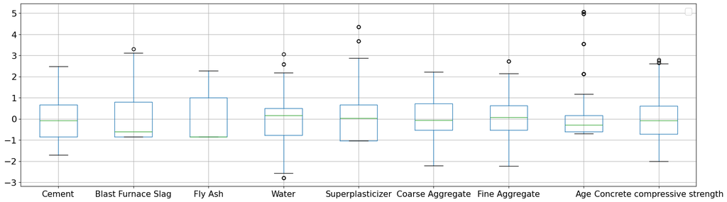

```python
#Creación de gráfico de boxplot
plt.figure(figsize=(22,6))
data_scaled.boxplot(grid=True,fontsize=15)
plt.legend(fontsize=16)
plt.yticks(fontsize=16)
plt.show()
```

## **Manejo de outliers 🧹**

Como nuestros métodos de detección de outliers confirmaron, hay variables que contienen outliers y afectarían el correcto analisis de las mismas. Para ello, optaremos por convertilos en valores faltantes para su posterior imputación. Esto lo haremos debido a que hay una variable con un gran número de outliers por lo que eliminarlos afectaría considerablemente el estudio.

```python
def replace_outliers_with_nan(df):
    data_out = data.copy()

    for col in data_out.columns:
        if pd.api.types.is_numeric_dtype(data_out[col]):
            Q1 = data_out[col].quantile(0.25)
            Q3 = data_out[col].quantile(0.75)
            IQR = Q3 - Q1
            lower_bound = Q1 - 1.5 * IQR
            upper_bound = Q3 + 1.5 * IQR

            outlier_mask = (data_out[col] < lower_bound) | (data_out[col] > upper_bound)
            data_out.loc[outlier_mask, col] = np.nan

            print(f"🧹 Reemplazados {outlier_mask.sum()} outliers con NaN en '{col}'")

    return data_out

data_Nan = replace_outliers_with_nan(data)
df_Nan = pd.DataFrame(data_Nan)
df_Nan
```

```
🧹 Reemplazados 0 outliers con NaN en 'Cement'
🧹 Reemplazados 2 outliers con NaN en 'Blast Furnace Slag'
🧹 Reemplazados 0 outliers con NaN en 'Fly Ash'
🧹 Reemplazados 9 outliers con NaN en 'Water'
🧹 Reemplazados 10 outliers con NaN en 'Superplasticizer'
🧹 Reemplazados 0 outliers con NaN en 'Coarse Aggregate'
🧹 Reemplazados 5 outliers con NaN en 'Fine Aggregate'
🧹 Reemplazados 59 outliers con NaN en 'Age'
🧹 Reemplazados 4 outliers con NaN en 'Concrete compressive strength'
```

|  | Cement | Blast Furnace Slag | Fly Ash | Water | Superplasticizer | Coarse Aggregate | Fine Aggregate | Age | Concrete compressive strength |
| --- | --- | --- | --- | --- | --- | --- | --- | --- | --- |
| 0 | 540.0 | 0.0 | 0.0 | 162.0 | 2.5 | 1040.0 | 676.0 | 28.0 | NaN |
| 1 | 540.0 | 0.0 | 0.0 | 162.0 | 2.5 | 1055.0 | 676.0 | 28.0 | 61.89 |
| 2 | 332.5 | 142.5 | 0.0 | 228.0 | 0.0 | 932.0 | 594.0 | NaN | 40.27 |
| 3 | 332.5 | 142.5 | 0.0 | 228.0 | 0.0 | 932.0 | 594.0 | NaN | 41.05 |
| 4 | 198.6 | 132.4 | 0.0 | 192.0 | 0.0 | 978.4 | 825.5 | NaN | 44.30 |
| ... | ... | ... | ... | ... | ... | ... | ... | ... | ... |
| 1025 | 276.4 | 116.0 | 90.3 | 179.6 | 8.9 | 870.1 | 768.3 | 28.0 | 44.28 |
| 1026 | 322.2 | 0.0 | 115.6 | 196.0 | 10.4 | 817.9 | 813.4 | 28.0 | 31.18 |
| 1027 | 148.5 | 139.4 | 108.6 | 192.7 | 6.1 | 892.4 | 780.0 | 28.0 | 23.70 |
| 1028 | 159.1 | 186.7 | 0.0 | 175.6 | 11.3 | 989.6 | 788.9 | 28.0 | 32.77 |
| 1029 | 260.9 | 100.5 | 78.3 | 200.6 | 8.6 | 864.5 | 761.5 | 28.0 | 32.40 |

1030 rows × 9 columns

```python
from sklearn.metrics import mean_squared_error, mean_absolute_error

def evaluate_imputation(original_df, imputed_df, df_with_nans):

    results = {'Feature': [], 'MSE': [], 'MAE': []}

    for column in original_df.columns:
        # Only evaluate where data was originally missing
        missing_mask = df_Nan[column].isna()

        if missing_mask.sum() > 0:
            original_values = original_df.loc[missing_mask, column]
            imputed_values = imputed_df.loc[missing_mask, column]

            mse = mean_squared_error(original_values, imputed_values)
            mae = mean_absolute_error(original_values, imputed_values)

            results['Feature'].append(column)
            results['MSE'].append(mse)
            results['MAE'].append(mae)

    return pd.DataFrame(results)
```

```python
from sklearn.ensemble import AdaBoostRegressor, BaggingRegressor, ExtraTreesRegressor, GradientBoostingRegressor, HistGradientBoostingRegressor, RandomForestRegressor
from sklearn.svm import SVR
from sklearn.linear_model import BayesianRidge, GammaRegressor, HuberRegressor, PoissonRegressor, Ridge, TheilSenRegressor, TweedieRegressor
from sklearn.neighbors import KNeighborsRegressor

from sklearn.experimental import enable_iterative_imputer
from sklearn.impute import IterativeImputer
```

```python
imp_RF = IterativeImputer(estimator=RandomForestRegressor(n_estimators=250),verbose=1,add_indicator=False)
imp_RF.fit(data_Nan)
data_imputed_RF=pd.DataFrame(imp_RF.transform(data_Nan),columns=data.columns)
```

```
[IterativeImputer] Completing matrix with shape (1030, 9)
[IterativeImputer] Change: 152.5664303501946, scaled tolerance: 1.145
[IterativeImputer] Change: 13.57360000000051, scaled tolerance: 1.145
[IterativeImputer] Change: 8.054399999999987, scaled tolerance: 1.145
[IterativeImputer] Change: 8.130399999999952, scaled tolerance: 1.145
[IterativeImputer] Change: 7.584000000000003, scaled tolerance: 1.145
[IterativeImputer] Change: 7.655200000000093, scaled tolerance: 1.145
[IterativeImputer] Change: 7.588000000000008, scaled tolerance: 1.145
[IterativeImputer] Change: 6.477600000001189, scaled tolerance: 1.145
[IterativeImputer] Change: 9.933599999999899, scaled tolerance: 1.145
[IterativeImputer] Change: 9.096000000000004, scaled tolerance: 1.145
[IterativeImputer] Completing matrix with shape (1030, 9)
```

```python
evaluation_results_iterative = evaluate_imputation(data, data_imputed_RF, data_Nan)
evaluation_results_iterative
```

|  | Feature | MSE | MAE |
| --- | --- | --- | --- |
| 0 | Blast Furnace Slag | 16389.187190 | 128.004200 |
| 1 | Water | 2347.566176 | 47.652311 |
| 2 | Superplasticizer | 400.406158 | 19.853107 |
| 3 | Fine Aggregate | 30727.576786 | 175.292160 |
| 4 | Age | 40956.068082 | 186.261220 |
| 5 | Concrete compressive strength | 406.350525 | 17.828062 |

```python
import pandas as pd
from sklearn.metrics import mean_absolute_error

def evaluar_errores(df_original, df_imputed):
    resultados = []

    for col in df_original.columns:
        mae = mean_absolute_error(df_original[col], df_imputed[col])
        media_real = df_original[col].mean()
        error_relativo = mae / media_real
        if error_relativo > 0.2:
            significativo = 'Sí'
        else:
            significativo = 'No'

        resultados.append({
            'Variable': col,
            'MAE': mae,
            'Media real': media_real,
            'Error relativo': error_relativo,
            '¿Error significativo?': significativo
        })

    return pd.DataFrame(resultados)

evaluar_errores(data,data_imputed_RF)
```

|  | Variable | MAE | Media real | Error relativo | ¿Error significativo? |
| --- | --- | --- | --- | --- | --- |
| 0 | Cement | 0.000000 | 281.167864 | 0.000000 | No |
| 1 | Blast Furnace Slag | 0.248552 | 73.895825 | 0.003364 | No |
| 2 | Fly Ash | 0.000000 | 54.188350 | 0.000000 | No |
| 3 | Water | 0.416379 | 181.567282 | 0.002293 | No |
| 4 | Superplasticizer | 0.192749 | 6.204660 | 0.031065 | No |
| 5 | Coarse Aggregate | 0.000000 | 972.918932 | 0.000000 | No |
| 6 | Fine Aggregate | 0.850933 | 773.580485 | 0.001100 | No |
| 7 | Age | 10.669332 | 45.662136 | 0.233658 | Sí |
| 8 | Concrete compressive strength | 0.069235 | 35.817961 | 0.001933 | No |

```
 - Variable: Cement
```

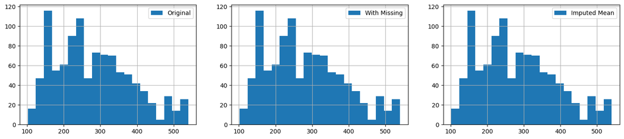

```
 - Variable: Blast Furnace Slag
```

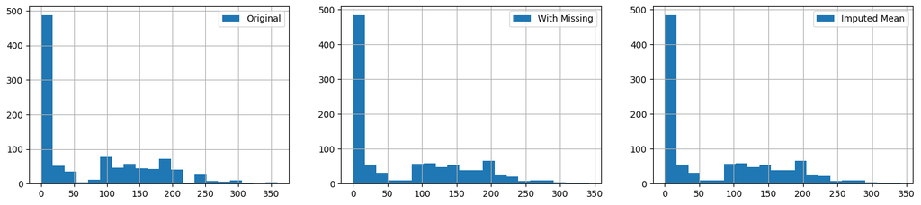

```
 - Variable: Fly Ash
```

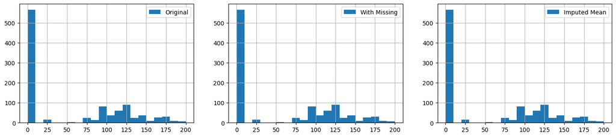

```
 - Variable: Water
```

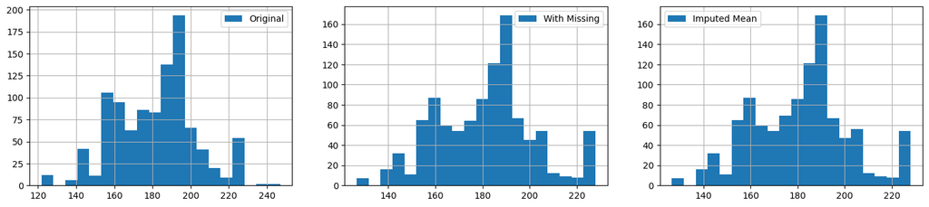

```
 - Variable: Superplasticizer
```

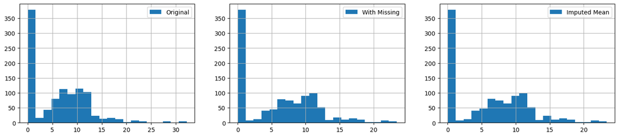

```
 - Variable: Coarse Aggregate
```

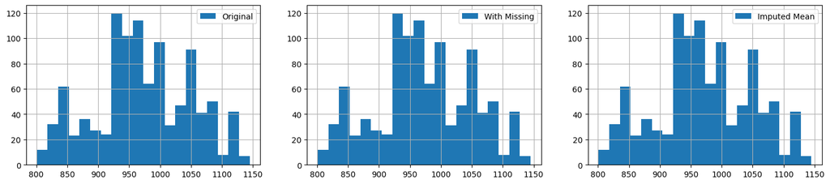

```
 - Variable: Fine Aggregate
```

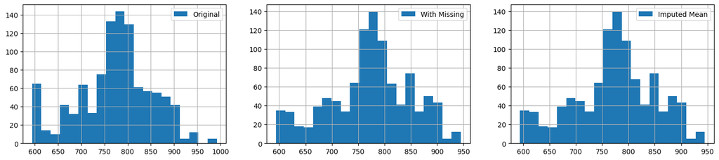

```
 - Variable: Age
```

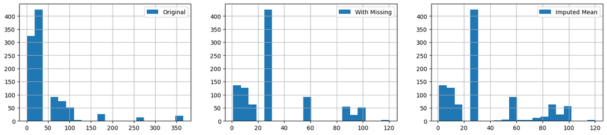

```
 - Variable: Concrete compressive strength
```

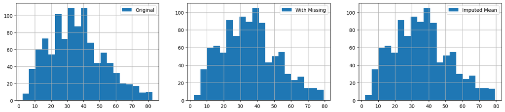

```python
for i in data.columns:
  print(f"\n - Variable: {i}")
  plt.figure(figsize=(18,8))
  plt.subplot(231)
  data[i].hist(bins=20,label="Original")
  plt.legend()
  plt.subplot(232)
  data_Nan[i].hist(bins=20,label="With Missing")
  plt.legend()
  plt.subplot(233)
  data_imputed_RF[i].hist(bins=20,label="Imputed Mean")
  plt.legend()
  plt.show()
```

```python
from scipy.stats import ks_2samp


for column in data.columns:
    _, p_value = ks_2samp(data[column], data_imputed_RF[column])

    print(f" Variable: {column}")
    print(f" P_value: {p_value:.4f}")

    if p_value > 0.05:
        print("✅ No hay diferencia significativa entre las distribuciones.")
    else:
        print("⚠️ Hay una diferencia significativa entre las distribuciones.")

    print("-" * 40)
```

```
 Variable: Cement
 P_value: 1.0000
✅ No hay diferencia significativa entre las distribuciones.
----------------------------------------
 Variable: Blast Furnace Slag
 P_value: 1.0000
✅ No hay diferencia significativa entre las distribuciones.
----------------------------------------
 Variable: Fly Ash
 P_value: 1.0000
✅ No hay diferencia significativa entre las distribuciones.
----------------------------------------
 Variable: Water
 P_value: 1.0000
✅ No hay diferencia significativa entre las distribuciones.
----------------------------------------
 Variable: Superplasticizer
 P_value: 1.0000
✅ No hay diferencia significativa entre las distribuciones.
----------------------------------------
 Variable: Coarse Aggregate
 P_value: 1.0000
✅ No hay diferencia significativa entre las distribuciones.
----------------------------------------
 Variable: Fine Aggregate
 P_value: 1.0000
✅ No hay diferencia significativa entre las distribuciones.
----------------------------------------
 Variable: Age
 P_value: 0.0681
✅ No hay diferencia significativa entre las distribuciones.
----------------------------------------
 Variable: Concrete compressive strength
 P_value: 1.0000
✅ No hay diferencia significativa entre las distribuciones.
----------------------------------------
```

# **Resumen de lo realizado:**

Para la detección de outliers, se aplicó el método basado en el Rango Intercuartílico. Esta metodo consiste en calcular el primer cuartil y el tercer cuartil de cada variable numérica,teniendo como resultado el rango intercuartílico . Los valores que se encuentran por debajo de Q1 - 1.5IQR o por encima de Q3 + 1.5IQR se consideran outliers. Esta metodologia es bastante efectiva para identificar valores extremos sin depender de supuestos de normalidad en la distribución de los datos. Luego de detectarlos, estos valores fueron reemplazados por NaN para imputarlos mediante un modelo de machine learning.

# **Conclusiones:**

**Impacto de los Outliers:**

Los outliers son valores extremos que pueden alterar significativamente los resultados de un análisis. En particular, su presencia tiende a distorsionar medidas fundamentales como la media, la desviación estándar y puede incluso afectar la calidad de los modelos predictivos al provocar sesgos. Durante este trabajo, se observó que los outliers modificaban la distribución natural de los datos, Razon por la cual se realizo todo el manejo para garantizar un análisis más confiable.

**Recomendaciones sobre el Manejo de Valores Extremos en Contextos Reales:**

En contextos reales, lo ideal seria que primero se analice mas o profundo la data y el contexto de los outliers para saber si estos son: errores, situaciónes que representen una excepción o que exista una variabilidad como tal en esos datos.No es recomendable eliminar los valores extremos sin antes tener en cuenta esos aspectos.Cuando finalmente se decide tratar estos datos se recomendaria usar metodos mas complejos de imputación (como: Random Forest, Gradient Boosting) o técnicas iterativas que respeten las relaciones entre variables. Finalmente, es esencial documentar el proceso de tratamiento de outliers para asegurar una transparencia en todo el proceso.

```python
from google.colab import drive
drive.mount('/content/drive')
```

```python
!jupyter nbconvert --to html '/content/drive/MyDrive/Colab Notebooks/Copia de Trabajo_Imputación.ipynb'
```